# Detección de Anomalías

# Introducción

El término anomalia se define como una colección de puntos de datos que no siguen el mismo patrón o no tienen la misma estructura que el resto de los datos. El objetivo de los métodos de detección de anomalías es encontrar estas desviaciones y así poder identificar los comportamientos atípicos(Amat,2020). Entre los métodos para la detección de datos anómalos se encuentran los métodos supervisados, semi-supervisados y no supervisados. En este informe se hace uso del método LOF(Factor local atípico) en la detección de anomalías, el cual es un algoritmo propuesto por Markus M. Breuning para encontrar puntos de datos anómalos midiendo la desviación local de un punto de datos dado con respecto a sus vecinos. Por otro lado se realiza un análisis multivariante unicamente con las variables cuantitativas de nuestros datos.

## Test de normalidad

Es muy útil visualizar la distribución de nuestros valores, detectar posibles errores y realizar pruebas de normalidad de los datos antes de empezar con nuestro análisis.

En siguiente gráfico representa los datos de las variables frente a los datos esperados si la distribución fuera normal . Si los puntos están cerca de la diagonal podemos decir que la distribución es normal. De igual forma se podría obtener un histograma que nos ayude a visualizar.

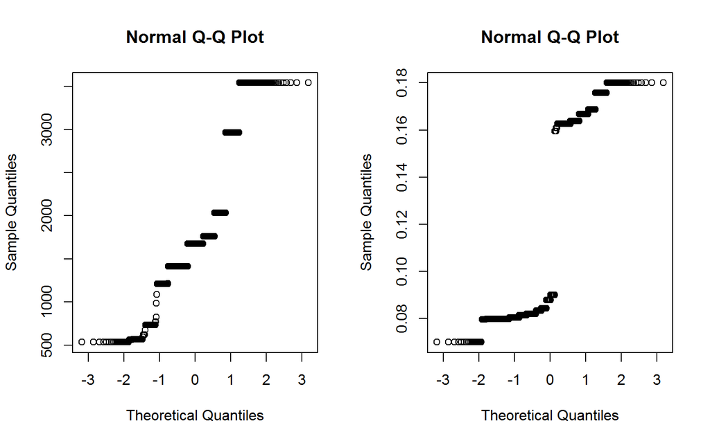

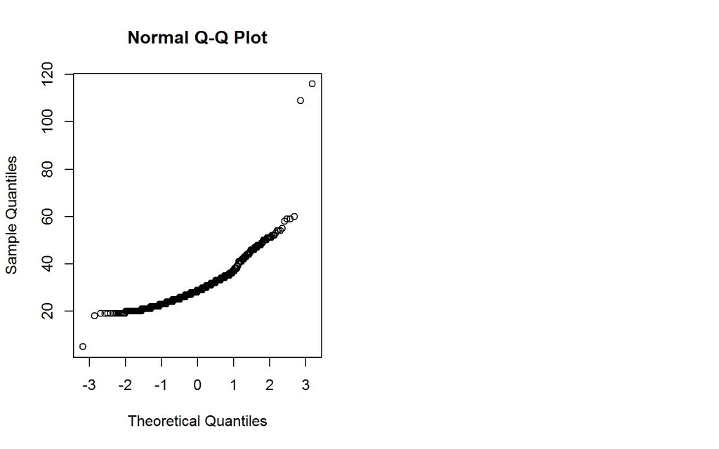

Ahora, Con la ayuda del paquete "normtest" se obtiene un test de normalidad que se utiliza mayormente para muestras pequeñas. Este test de normalidad se enfrenta a una $H_{0}$= los datos provienen de una distribución normal VS $H_{a}$= No provienen de una distribución normal.

```
##
##  Shapiro-Wilk normality test
##
## data:  portantes_Fondo_Anomalias$REMUNERACION_MES
## W = 0.87948, p-value < 2.2e-16
```

```
##
##  Shapiro-Wilk normality test
##
## data:  portantes_Fondo_Anomalias$PC_APORTE
## W = 0.73226, p-value < 2.2e-16
```

```
##
##  Shapiro-Wilk normality test
##
## data:  portantes_Fondo_Anomalias$años
## W = 0.82201, p-value < 2.2e-16
```

## Detección de Outliers: Técnicas multivariadas

A partir de datos obtenidos previamente en el informe de ACP se obtuvo que las variables años, pc_aporte y remuneración mensual fueron las más influyentes en nuestro análisis, a partir de estos datos la siguiente gráfica nos muestra una nube de puntos tridimensionales que nos permite identificar a partir de las 3 variables influyentes los valores anómalos.

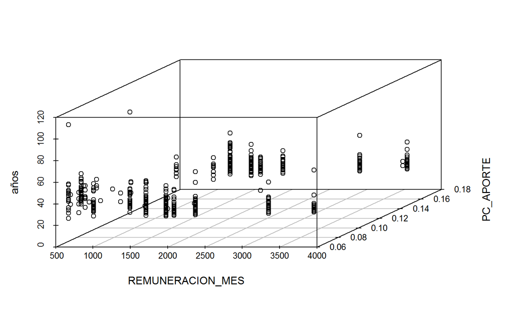

## Local Outlier Factor(LOF)

Ahora abordamos, Local Outlier Factor que es una técnica multivariada. La idea de LOF será encontrar los outlieres de nuestra base datos basandose en un concepto de densidad local, dónde la localidad está dada por $k$ vecinos más cercanos, cuya distancia se usa para estimar la densidad.

```
## [1] 233 140 680   7 534  92
```

La siguiente gráfica de densidad también nos ayuda a visualizar la distribución de datos en un intervalo de tiempo continuo. Este gráfico será una variación de un histograma.

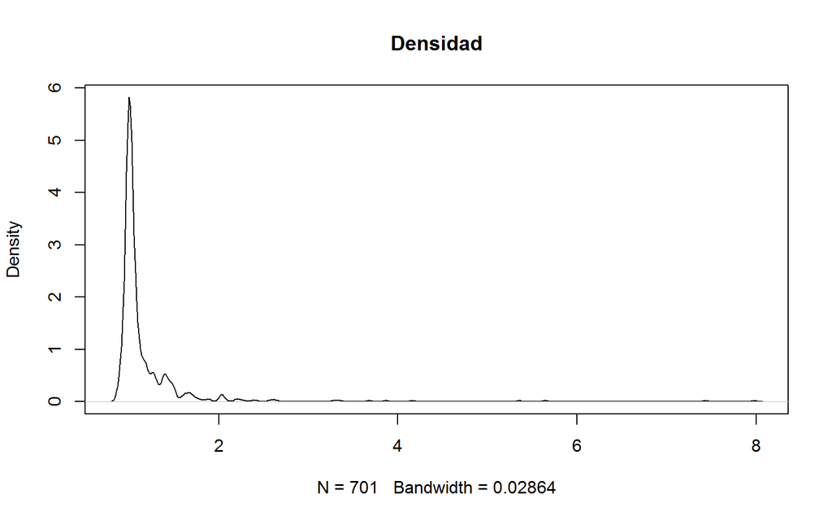

## Datos anómalos significativos

Se identifica cuales son los outliers con un nivel de significancia del 0.95% para posteriormente retirarlos calculando previamente los cuantiles .

```
##        0%       25%       50%       75%      100%
## 0.8846154 0.9960880 1.0218460 1.1542004 7.9791466
```

```r
out_index=which(portantes_lof>= thr)
out_index
```

```
##  [1]   7  19  47  55  70  92 131 140 148 160 175 214 233 236 255 277 288 289 298
## [20] 306 345 364 379 393 438 441 496 534 544 554 607 621 646 668 680 701
```

La siguiente gráfica nos muestra los outliers representados por color rojo partiendo del cálculo de lo LOF para k=5 vecinos por instancia.

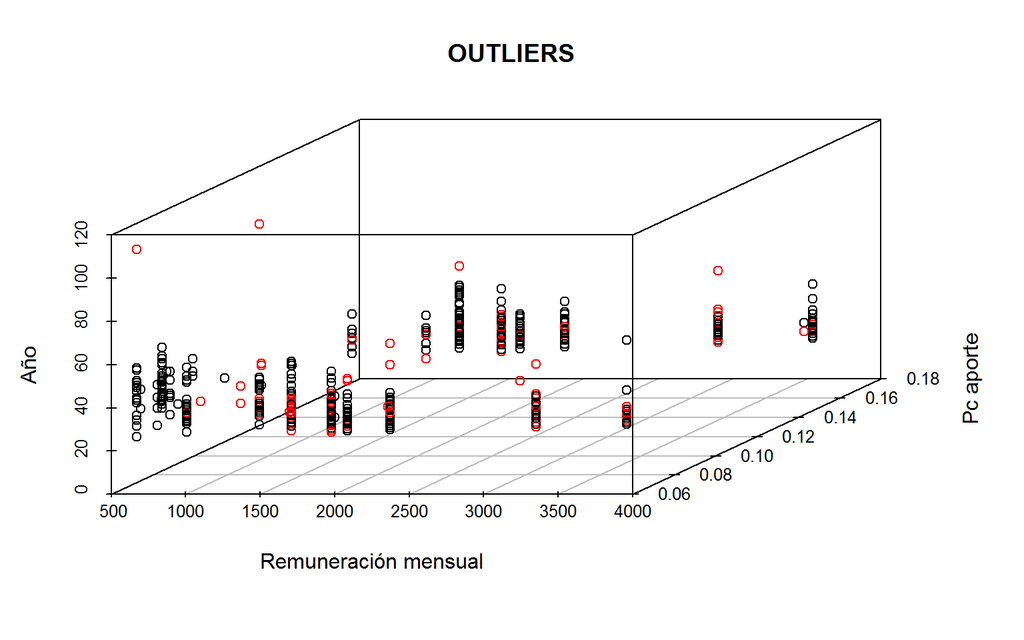

## LOF vs KNN

Con nuestra base datos escalada primero se calcula y se agrega la distancia KNN como una nueva columna. Luego se calcula y se agrega LOF como una nueva columna para finalmente encontrar la ubicación de la fila del KNN y LOF más alto .

Se concluye que mediante LOF Y KNN se obtiene el mismo valor $233$

```
## [1] 233
```

```
## [1] 233
```

### Ruidos

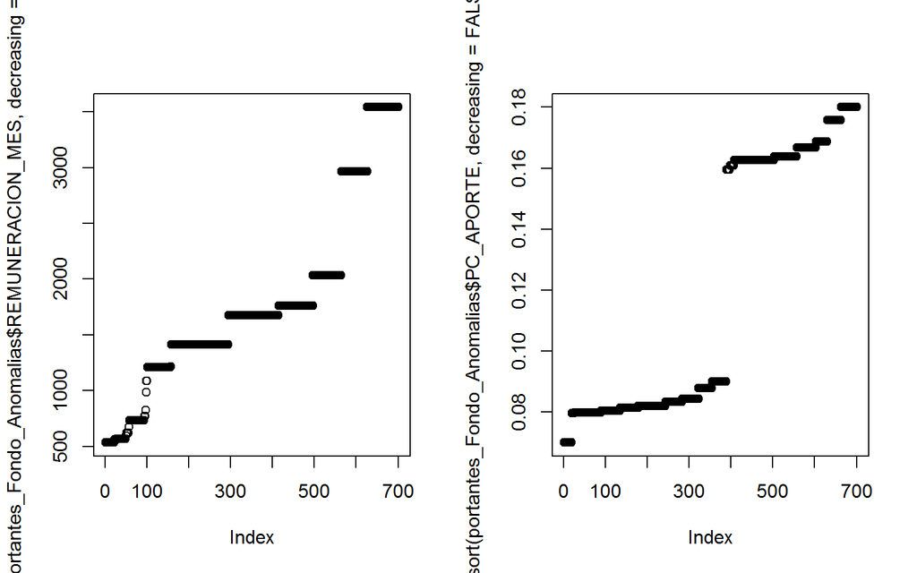

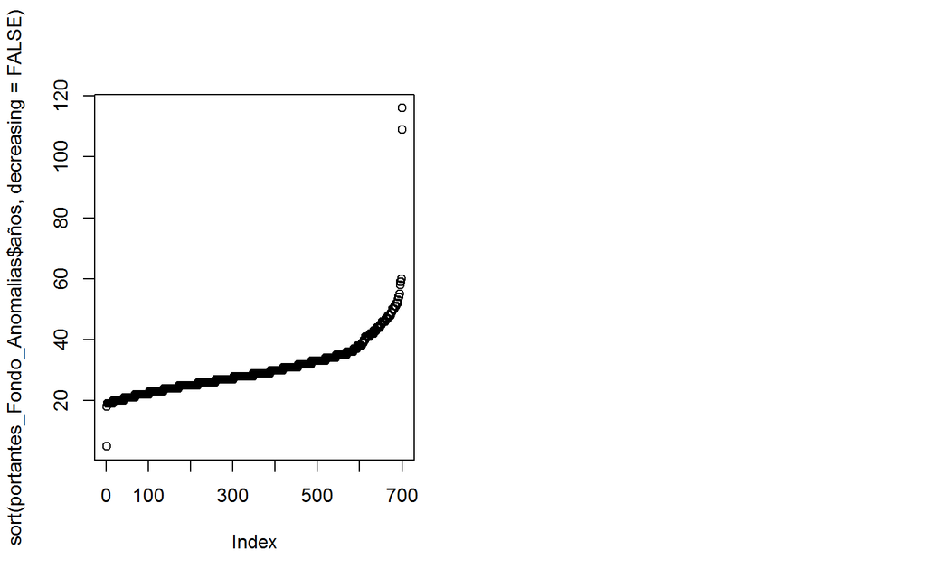